# Part II - (Ford GO Bike Exploration)

## by (Winner Abiodun)

## Investigation Overview

> This exploration deal with the relationship betweem Trip Duration and Distance as a Function of the trips made with the Ford Go Bike system for the month of February 2019. The Columns of interest includes the Age Groups, The Start time and End time, the Type of users, whether those users use Bikes for all round trips and the user Gender.

## Dataset Overview

> The Dataset is quite Large with over 183000 rows of observations and 16 columns that describe each trip characteristics. After wrangling, The dataset was reduced to over 174000 rows and 13 colums. For our analysis new Features such as Start and End week days, start and end week hours, Distance and age were created from the existing ones in order to get insight from the data.

# Univariate Analysis

### Distribution of Duration in Minutes

> The visual shows the duration plotted in minutes, with a lot of outliers trailing up to 140 minutes. However the datapoints are concentrated between 0 and 20mins. which is the same observation when using Log Transformation.

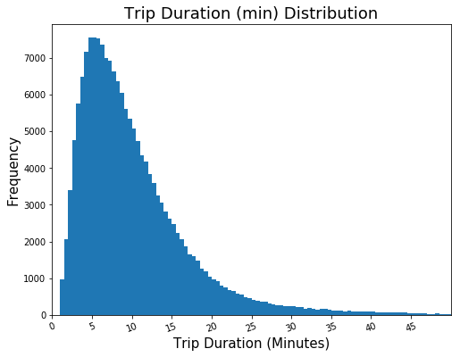

```python
ford["duration_min"]=round((ford["duration_sec"]/60), 2)# Plot the distribution
# Plot the distribution of duration minutes to cross validate our findings
plt.figure(figsize=[8,6])
bins=np.arange(ford.duration_min.min(), ford.duration_min.max()+0.5, 0.5)
plt.hist(data=ford, x="duration_min", bins=bins)
plt.xlim(0,50)
plt.xticks(np.arange(0,50,5), rotation=20)
# Set axis labels
plt.xlabel("Trip Duration (Minutes)", fontsize=15)
plt.ylabel("Frequency", fontsize=15)
plt.title("Trip Duration (min) Distribution", fontsize=18)

plt.show()
```

### Distribution of Distance

> The dataset included longitude and latitudes of the start and end stations, from which the distance feature was created to measure travel distance. Most trips between stations covers a distance between 0-3km

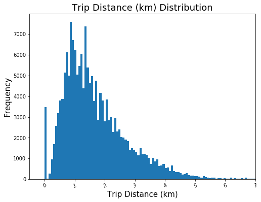

```python
# Plot the distribution of distance
plt.figure(figsize=[8,6])
bins = np.arange(0,70,0.07)
plt.hist(data=ford, x="distance", bins=bins)
# Set Axis tick label
plt.xticks(np.arange(-1,10,1), rotation=20)
# Set Axis limit
plt.xlim(-0.5,7)
# Set axis labels
plt.xlabel("Trip Distance (km)", fontsize=15)
plt.ylabel("Frequency", fontsize=15)
plt.title("Trip Distance (km) Distribution", fontsize=18)

plt.show()
```

### Distribution of Start and End Week days

> From the start and end time column a new columns were created to depict the start days and end days. Most Frequent start and end days are Tuesdays, Wednesdays, Thursdays and Fridays

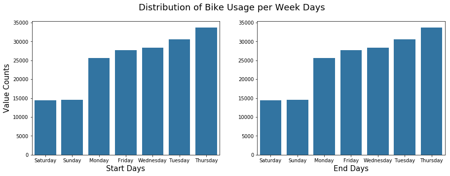

```python
# Set axis area
plt.figure(figsize=[15,5])
# set title
plt.suptitle("Distribution of Bike Usage per Week Days", fontsize=18)

# Set colour
color=sb.color_palette()[0]

# Plot 1 showing normal pie chart
plt.subplot(1,2,1)
order_s=ford.groupby("start_week_days")["duration_sec"].count().sort_values().index
sb.countplot(data=ford, x="start_week_days", color=color, order=order_s)
plt.xlabel("Start Days", fontsize=15)
plt.ylabel("Value Counts", fontsize=15)

# Plot 2 showing Exploded portion of pie chart
plt.subplot(1,2,2)
order_e=ford.groupby("end_week_days")["duration_sec"].count().sort_values().index
sb.countplot(data= ford, x="end_week_days", color=color, order=order_e)
plt.xlabel("End Days", fontsize=15)
plt.ylabel("")

plt.show()
```

### Distribution of Start and End Hours

> From the start and end time column a new columns were created to depict the start and end Trip hours per day

> From the visual its clear that the Most Frequent start and end The most common Trip start and end times are the 17th, 8th, 18th, 9th and 16th hour which translates to 5pm, 8am, 6pm, 9am and 4pm.

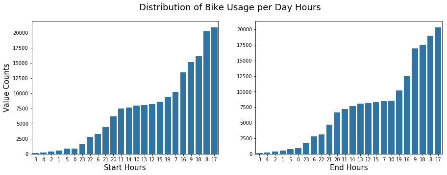

```python
# Set axis area
plt.figure(figsize=[15,5])
# set title
plt.suptitle("Distribution of Bike Usage per Day Hours", fontsize=18)

# Set colour
color=sb.color_palette()[0]

# Plot 1 showing normal pie chart
plt.subplot(1,2,1)
order_s=ford.groupby("start_hour")["duration_sec"].count().sort_values().index
sb.countplot(data=ford, x="start_hour", color=color, order=order_s)
plt.xlabel("Start Hours", fontsize=15)
plt.ylabel("Value Counts", fontsize=15)

# Plot 2 showing Exploded portion of pie chart
plt.subplot(1,2,2)
order_e=ford.groupby("end_hour")["duration_sec"].count().sort_values().index
sb.countplot(data= ford, x="end_hour", color=color, order=order_e)
plt.xlabel("End Hours", fontsize=15)
plt.ylabel("")

plt.show()
```

### User Type Distribution

> The distribution shows that over 90% of Bike users are Subscribers and less than 10% of Bike users are Customers

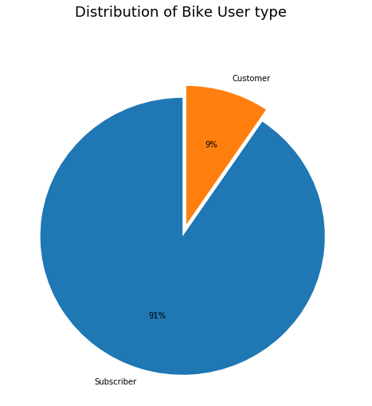

```python
# Set axis area
plt.figure(figsize=[8,8])
# set title
plt.suptitle("Distribution of Bike User type", fontsize=18)

explode=[0.09,0]
plt.pie(type_counts, labels=type_counts.index, startangle=90, autopct="%.0f%%", explode=explode  )


plt.show()
```

### Distibution of Gender

> The distribution shows that 75% of users are male, 23% are Female and about 2% are gender type other

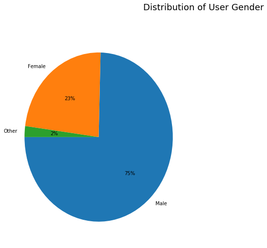

```python
# Set axis area
plt.figure(figsize=[15,8])
# set title
plt.suptitle("Distribution of User Gender", fontsize=18)

# Plot 1 showing normal pie chart
plt.subplot(1,2,1)
plt.pie(gender_counts, labels=gender_counts.index, startangle=180, autopct="%.0f%%")

plt.show()
```

### Distribution of Bike Usership for all round Trips

> The Distribution shows that only about 10% of users use Bikes for all round trips, about 90% do not!

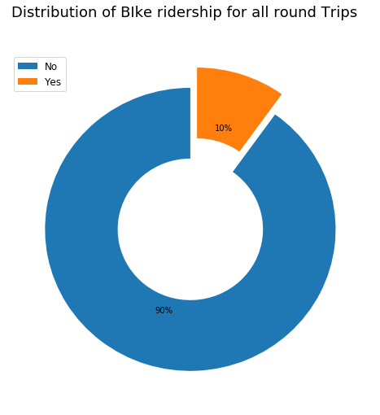

```python
# Set axis area
plt.figure(figsize=[8,8])
# set title
plt.suptitle("Distribution of BIke ridership for all round Trips", fontsize=18)

explode=[0,0.15]
plt.pie(trip_counts,startangle=90, autopct="%.0f%%", wedgeprops={"width":0.5}, explode=explode)
plt.legend(["No","Yes"],loc="upper left",fontsize=12)


plt.show()
```

### Distribution of Age Groups

> The distribution shows that most bike users are between the age range of 29 and 39 years

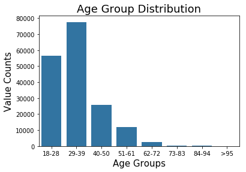

```python
# Plot the age group distribution
sb.countplot(data=ford, x="age_group", color=color)
# Set axis labels
plt.title("Age Group Distribution", fontsize=18)
plt.xlabel("Age Groups", fontsize=15)
plt.ylabel("Value Counts", fontsize=15)

plt.show()
```

## Bivariate Exploration

### Distribution of Duration in Minutes and Distance in Kilometers

> This shows that most Trips Have a distance of less than 20km and the most part of the duration are concentrated between 0mins and 80mins

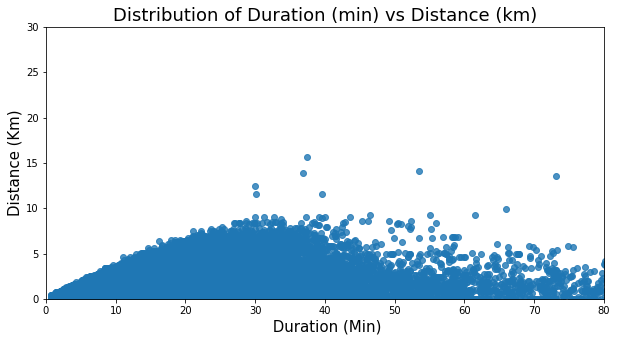

```python
plt.figure(figsize=(10,5))
sb.regplot(data=ford, fit_reg=False, x="duration_min", y="distance", x_jitter=0.3)
plt.xlim(0,80)
plt.ylim(0,30)
plt.xlabel(" Duration (Min)", fontsize=15)
plt.ylabel("Distance (Km)", fontsize=15)
plt.title("Distribution of Duration (min) vs Distance (km)", fontsize=18)

plt.show()
```

### Distribution of the Trip Duration and User Type

> Most customers spend an average 20-22mins on trips while Subscribers spend between 10-12mins

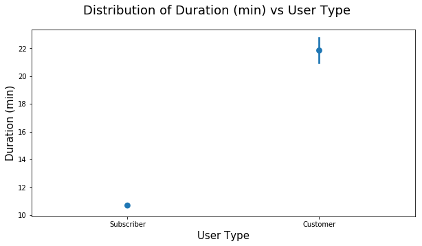

```python
plt.figure(figsize=[10,5])
plt.suptitle("Distribution of Duration (min) vs User Type", fontsize=18)

sb.pointplot(y="duration_min", x="user_type", data=ford, linestyles="")
plt.xlabel("User Type", fontsize=15)
plt.ylabel("Duration (min)", fontsize=15)

plt.show()
```

### Distribution of Trip Duration and Start Week days

> This pointplot shows that the highest time is spent jorneying on sundays and saturdays than anyother day

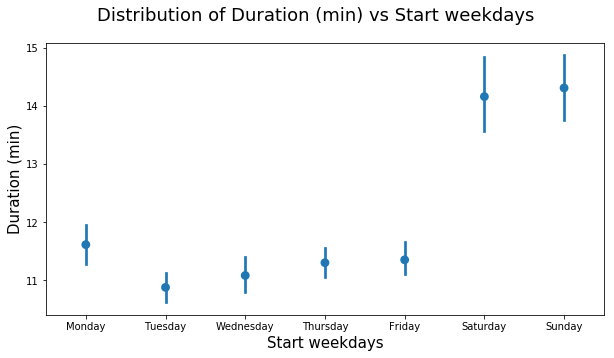

```python
plt.figure(figsize=[10,5])
plt.suptitle("Distribution of Duration (min) vs Start weekdays", fontsize=18)

sb.pointplot(x="start_week_days", y="duration_min", data=ford, linestyles="")
plt.xlabel("Start weekdays", fontsize=15)
plt.ylabel("Duration (min)", fontsize=15)
plt.show()
```

### Distribution of Trip Duration and Start Hours

> This shows that most trips that start by midnight, especially at 3am tend to be longer.

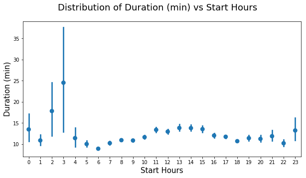

```python
plt.figure(figsize=[10,5])
plt.suptitle("Distribution of Duration (min) vs Start Hours", fontsize=18)

sb.pointplot(x="start_hour", y="duration_min", data=ford, linestyles="")
plt.xlabel("Start Hours", fontsize=15)
plt.ylabel("Duration (min)", fontsize=15)
plt.show()
```

### Distribution of Trip Distance and Start hours

> Trips that start by 5am and 8am tend to long distance travels

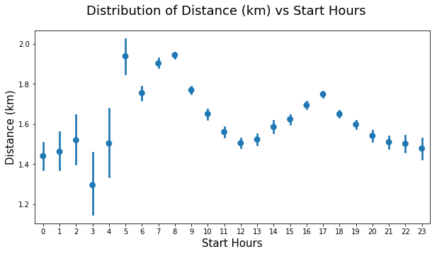

```python
plt.figure(figsize=[10,5])
plt.suptitle("Distribution of Distance (km) vs Start Hours", fontsize=18)

sb.pointplot(x="start_hour", y="distance", data=ford, linestyles="")
plt.xlabel("Start Hours", fontsize=15)
plt.ylabel("Distance (km)", fontsize=15)
plt.show()
```

### Distribution of Trip Distance and Start weekdays

> Trips that start on Tuesdays, Thursdays and Fridays Tend to cover more km in travel

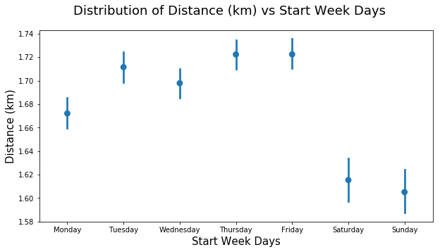

```python
plt.figure(figsize=[10,5])
plt.suptitle("Distribution of Distance (km) vs Start Week Days", fontsize=18)

sb.pointplot(x="start_week_days", y="distance", data=ford, linestyles="")
plt.xlabel("Start Week Days", fontsize=15)
plt.ylabel("Distance (km)", fontsize=15)
plt.show()
```

# Multivariate Exploration

### Distribution of Trip Duration, Bike Usership for All Trips and Age Group

> The Visual shows that users between age group 29-70 use bike for all round trips and spend the highest travel time as well as customers between age group 73-83 and 95years who do not use bike for all round trips

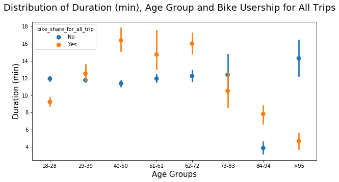

```python
plt.figure(figsize=[10,5])
plt.suptitle("Distribution of Duration (min), Age Group and Bike Usership for All Trips", fontsize=18)

sb.pointplot(y="duration_min", x="age_group",hue="bike_share_for_all_trip", data=ford, linestyles="")
plt.xlabel("Age Groups", fontsize=15)
plt.ylabel("Duration (min)",fontsize=15)

plt.show()
```

### Distribtution of Trip Distance User Type and Start Hours

> The visual shows that customers generally cover more travel distance than subscribers at everyother time of the day except for hors between 3am and 5am. where subscribers cover more distance than customers. The visual also shows that 5am subscribers and 7am-9am Customers cover the most distance

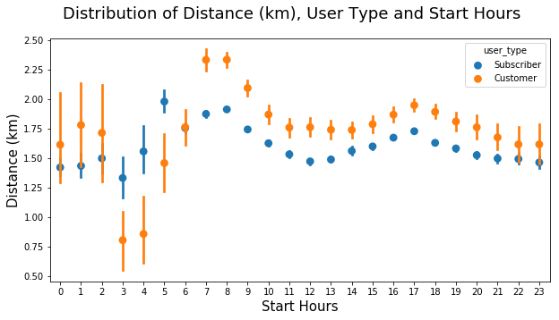

```python
plt.figure(figsize=[10,5])
plt.suptitle("Distribution of Distance (km), User Type and Start Hours", fontsize=18)

sb.pointplot(x="start_hour", y="distance", hue="user_type", data=ford, linestyles="")
plt.xlabel("Start Hours", fontsize=15)
plt.ylabel("Distance (km)", fontsize=15)
plt.show()
```

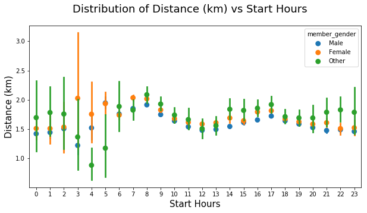

```python
plt.figure(figsize=[10,5])
plt.suptitle("Distribution of Distance (km) vs Start Hours", fontsize=18)

sb.pointplot(x="start_hour", y="distance", hue="member_gender", data=ford, linestyles="")
plt.xlabel("Start Hours", fontsize=15)
plt.ylabel("Distance (km)", fontsize=15)
plt.show()
```

### Distribution of Trip Duration, Age Groups and Weekdays

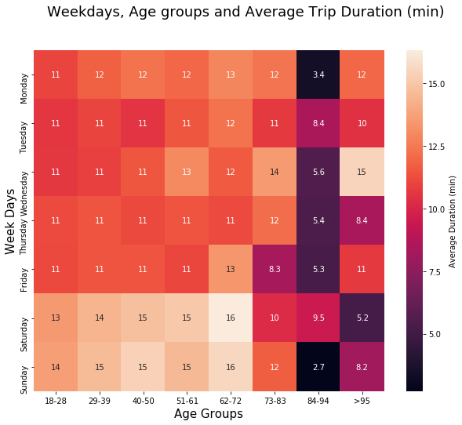

```python
cate = ford.groupby(["age_group","start_week_days"]).mean()["duration_min"].reset_index(name="avg_duration")
cate = cate.pivot_table(index="start_week_days", columns="age_group", values="avg_duration")

plt.figure(figsize=[10,8])
plt.suptitle("Weekdays, Age groups and Average Trip Duration (min)", fontsize=18)
sb.heatmap(cate, annot=True,cbar_kws = {'label' : 'Average Duration (min)'})
plt.xlabel("Age Groups", fontsize=15)
plt.ylabel("Week Days", fontsize=15)
plt.show()
```

### Distribution of Trip Duration, Weekdays, Gender and User Type

> The visual shows that customers of all genders use more trip time than subscribers. Male subscibers also use the least trip time across the weekdays but use more time on trips during weekends

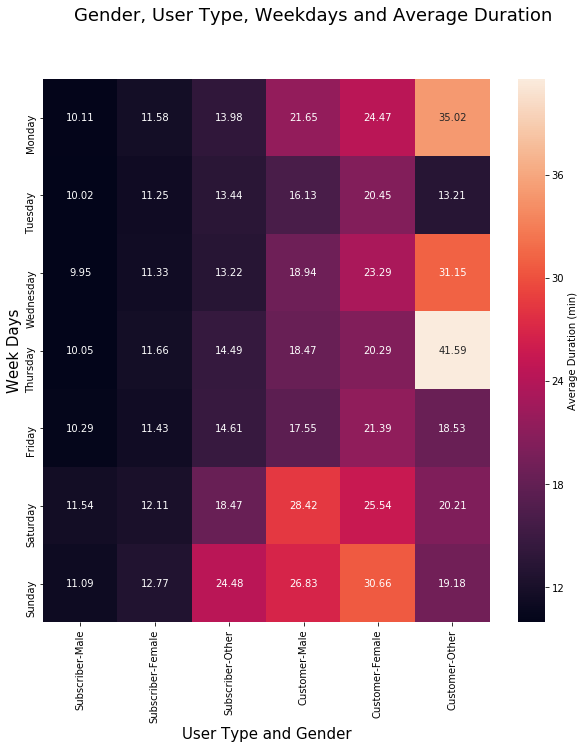

```python
cate = ford.groupby(["start_week_days","member_gender","user_type"]).mean()["duration_min"].reset_index(name="avg_distance")
cate = cate.pivot_table(index="start_week_days", columns=["user_type","member_gender"], values="avg_distance")

plt.figure(figsize=[10,10])
plt.suptitle("Gender, User Type, Weekdays and Average Duration", fontsize=18)
sb.heatmap(cate, annot=True,fmt=".02f",cbar_kws = {'label' : 'Average Duration (min)'})
plt.xlabel("User Type and Gender",fontsize=15)
plt.ylabel("Week Days",fontsize=15)

plt.show()
```

### Distribution of Trip Distance, Weekdays, Gender and User Type

> The visual shows that customers of all genders cover more distance than subscribers. Male subscibers also cover the least distance across especially at weekends

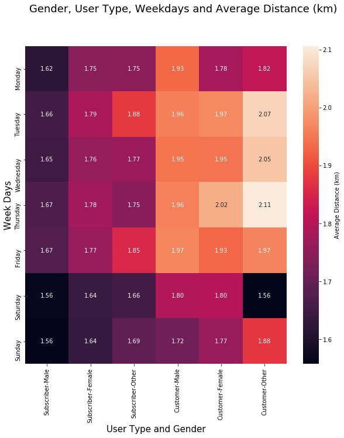

```python
cate = ford.groupby(["start_week_days","member_gender","user_type"]).mean()["distance"].reset_index(name="avg_distance")
cate = cate.pivot_table(index="start_week_days", columns=["user_type","member_gender"], values="avg_distance")

plt.figure(figsize=[10,10])
plt.suptitle("Gender, User Type, Weekdays and Average Distance (km)", fontsize=18)
sb.heatmap(cate, annot=True,fmt=".02f",cbar_kws = {'label' : 'Average Distance (km)'})
plt.xlabel("User Type and Gender",fontsize=15)
plt.ylabel("Week Days",fontsize=15)

plt.show()
```